# Risk Factor Analysis

## Outcome Variable

**Outcome Variable:** whz

## Predictor Variables

**Intervention Variable:** hdlvry

**Adjustment Set:**

- arm
- sex
- W_mage
- meducyrs
- feducyrs
- hhwealth_quart
- single
- W_nrooms
- brthmon
- W_parity
- impsan
- delta_W_mage
- delta_meducyrs
- delta_feducyrs
- delta_hhwealth_quart
- delta_single
- delta_W_nrooms
- delta_brthmon
- delta_W_parity
- delta_impsan

## Stratifying Variables

The analysis was stratified on these variable(s):

- agecat
- studyid
- country

## Data Summary

| agecat | studyid | country | hdlvry | n_cell | n | outcome_variable |
| --- | --- | --- | --- | --- | --- | --- |
| Birth | CMC-V-BCS-2002 | INDIA | 0 | 86 | 86 | whz |
| Birth | CMC-V-BCS-2002 | INDIA | 1 | 0 | 86 | whz |
| Birth | COHORTS | INDIA | 0 | 2763 | 4389 | whz |
| Birth | COHORTS | INDIA | 1 | 1626 | 4389 | whz |
| Birth | EE | PAKISTAN | 0 | 120 | 175 | whz |
| Birth | EE | PAKISTAN | 1 | 55 | 175 | whz |
| Birth | GMS-Nepal | NEPAL | 0 | 143 | 596 | whz |
| Birth | GMS-Nepal | NEPAL | 1 | 453 | 596 | whz |
| Birth | IRC | INDIA | 0 | 337 | 343 | whz |
| Birth | IRC | INDIA | 1 | 6 | 343 | whz |
| Birth | JiVitA-3 | BANGLADESH | 0 | 27 | 292 | whz |
| Birth | JiVitA-3 | BANGLADESH | 1 | 265 | 292 | whz |
| Birth | JiVitA-4 | BANGLADESH | 0 | 500 | 2384 | whz |
| Birth | JiVitA-4 | BANGLADESH | 1 | 1884 | 2384 | whz |
| Birth | NIH-Crypto | BANGLADESH | 0 | 548 | 707 | whz |
| Birth | NIH-Crypto | BANGLADESH | 1 | 159 | 707 | whz |
| Birth | PROVIDE | BANGLADESH | 0 | 387 | 532 | whz |
| Birth | PROVIDE | BANGLADESH | 1 | 145 | 532 | whz |
| Birth | SAS-CompFeed | INDIA | 0 | 108 | 957 | whz |
| Birth | SAS-CompFeed | INDIA | 1 | 849 | 957 | whz |
| 6 months | CMC-V-BCS-2002 | INDIA | 0 | 357 | 365 | whz |
| 6 months | CMC-V-BCS-2002 | INDIA | 1 | 8 | 365 | whz |
| 6 months | COHORTS | INDIA | 0 | 2896 | 4694 | whz |
| 6 months | COHORTS | INDIA | 1 | 1798 | 4694 | whz |
| 6 months | EE | PAKISTAN | 0 | 252 | 373 | whz |
| 6 months | EE | PAKISTAN | 1 | 121 | 373 | whz |
| 6 months | GMS-Nepal | NEPAL | 0 | 129 | 528 | whz |
| 6 months | GMS-Nepal | NEPAL | 1 | 399 | 528 | whz |
| 6 months | IRC | INDIA | 0 | 400 | 408 | whz |
| 6 months | IRC | INDIA | 1 | 8 | 408 | whz |
| 6 months | JiVitA-3 | BANGLADESH | 0 | 39 | 334 | whz |
| 6 months | JiVitA-3 | BANGLADESH | 1 | 295 | 334 | whz |
| 6 months | JiVitA-4 | BANGLADESH | 0 | 1082 | 4042 | whz |
| 6 months | JiVitA-4 | BANGLADESH | 1 | 2960 | 4042 | whz |
| 6 months | NIH-Crypto | BANGLADESH | 0 | 554 | 715 | whz |
| 6 months | NIH-Crypto | BANGLADESH | 1 | 161 | 715 | whz |
| 6 months | PROVIDE | BANGLADESH | 0 | 450 | 603 | whz |
| 6 months | PROVIDE | BANGLADESH | 1 | 153 | 603 | whz |
| 6 months | SAS-CompFeed | INDIA | 0 | 147 | 1088 | whz |
| 6 months | SAS-CompFeed | INDIA | 1 | 941 | 1088 | whz |
| 6 months | SAS-FoodSuppl | INDIA | 0 | 76 | 380 | whz |
| 6 months | SAS-FoodSuppl | INDIA | 1 | 304 | 380 | whz |
| 6 months | TanzaniaChild2 | TANZANIA, UNITED REPUBLIC OF | 0 | 1888 | 1920 | whz |
| 6 months | TanzaniaChild2 | TANZANIA, UNITED REPUBLIC OF | 1 | 32 | 1920 | whz |
| 24 months | CMC-V-BCS-2002 | INDIA | 0 | 361 | 369 | whz |
| 24 months | CMC-V-BCS-2002 | INDIA | 1 | 8 | 369 | whz |
| 24 months | COHORTS | INDIA | 0 | 2214 | 3533 | whz |
| 24 months | COHORTS | INDIA | 1 | 1319 | 3533 | whz |
| 24 months | EE | PAKISTAN | 0 | 112 | 167 | whz |
| 24 months | EE | PAKISTAN | 1 | 55 | 167 | whz |
| 24 months | GMS-Nepal | NEPAL | 0 | 118 | 455 | whz |
| 24 months | GMS-Nepal | NEPAL | 1 | 337 | 455 | whz |
| 24 months | IRC | INDIA | 0 | 401 | 409 | whz |
| 24 months | IRC | INDIA | 1 | 8 | 409 | whz |
| 24 months | JiVitA-3 | BANGLADESH | 0 | 34 | 289 | whz |
| 24 months | JiVitA-3 | BANGLADESH | 1 | 255 | 289 | whz |
| 24 months | JiVitA-4 | BANGLADESH | 0 | 1032 | 3993 | whz |
| 24 months | JiVitA-4 | BANGLADESH | 1 | 2961 | 3993 | whz |
| 24 months | NIH-Crypto | BANGLADESH | 0 | 391 | 514 | whz |
| 24 months | NIH-Crypto | BANGLADESH | 1 | 123 | 514 | whz |
| 24 months | PROVIDE | BANGLADESH | 0 | 433 | 579 | whz |
| 24 months | PROVIDE | BANGLADESH | 1 | 146 | 579 | whz |
| 24 months | TanzaniaChild2 | TANZANIA, UNITED REPUBLIC OF | 0 | 6 | 6 | whz |
| 24 months | TanzaniaChild2 | TANZANIA, UNITED REPUBLIC OF | 1 | 0 | 6 | whz |

The following strata were considered:

- agecat: 24 months, studyid: CMC-V-BCS-2002, country: INDIA
- agecat: 24 months, studyid: COHORTS, country: INDIA
- agecat: 24 months, studyid: EE, country: PAKISTAN
- agecat: 24 months, studyid: GMS-Nepal, country: NEPAL
- agecat: 24 months, studyid: IRC, country: INDIA
- agecat: 24 months, studyid: JiVitA-3, country: BANGLADESH
- agecat: 24 months, studyid: JiVitA-4, country: BANGLADESH
- agecat: 24 months, studyid: NIH-Crypto, country: BANGLADESH
- agecat: 24 months, studyid: PROVIDE, country: BANGLADESH
- agecat: 24 months, studyid: TanzaniaChild2, country: TANZANIA, UNITED REPUBLIC OF
- agecat: 6 months, studyid: CMC-V-BCS-2002, country: INDIA
- agecat: 6 months, studyid: COHORTS, country: INDIA
- agecat: 6 months, studyid: EE, country: PAKISTAN
- agecat: 6 months, studyid: GMS-Nepal, country: NEPAL
- agecat: 6 months, studyid: IRC, country: INDIA
- agecat: 6 months, studyid: JiVitA-3, country: BANGLADESH
- agecat: 6 months, studyid: JiVitA-4, country: BANGLADESH
- agecat: 6 months, studyid: NIH-Crypto, country: BANGLADESH
- agecat: 6 months, studyid: PROVIDE, country: BANGLADESH
- agecat: 6 months, studyid: SAS-CompFeed, country: INDIA
- agecat: 6 months, studyid: SAS-FoodSuppl, country: INDIA
- agecat: 6 months, studyid: TanzaniaChild2, country: TANZANIA, UNITED REPUBLIC OF
- agecat: Birth, studyid: CMC-V-BCS-2002, country: INDIA
- agecat: Birth, studyid: COHORTS, country: INDIA
- agecat: Birth, studyid: EE, country: PAKISTAN
- agecat: Birth, studyid: GMS-Nepal, country: NEPAL
- agecat: Birth, studyid: IRC, country: INDIA
- agecat: Birth, studyid: JiVitA-3, country: BANGLADESH
- agecat: Birth, studyid: JiVitA-4, country: BANGLADESH
- agecat: Birth, studyid: NIH-Crypto, country: BANGLADESH
- agecat: Birth, studyid: PROVIDE, country: BANGLADESH
- agecat: Birth, studyid: SAS-CompFeed, country: INDIA

### Dropped Strata

Some strata were dropped due to rare outcomes:

- agecat: Birth, studyid: CMC-V-BCS-2002, country: INDIA
- agecat: 24 months, studyid: TanzaniaChild2, country: TANZANIA, UNITED REPUBLIC OF

## Methods Detail

We’re interested in the causal parameters $E[Y_a]$ for all values of $a \in \mathcal{A}$. These parameters represent the mean outcome if, possibly contrary to fact, we intervened to set all units to have $A=a$. Under the randomization and positivity assumptions, these are identified by the statistical parameters $\psi_a=E_W[E_{Y|A,W}(Y|A=a,W)]$. In addition, we’re interested in the mean of $Y$, $E[Y]$ under no intervention (the observed mean). We will estimate these parameters by using SuperLearner to fit the relevant likelihood factors – $E_{Y|A,W}(Y|A=a,W)$ and $p(A=a|W)$, and then updating our likelihood fit using a joint TMLE.

For unadjusted analyses ($W=\{\}$), initial likelihoods were estimated using Lrnr_glm to estimate the simple $E(Y|A)$ and Lrnr_mean to estimate $p(A)$. For adjusted analyses, a small library containing Lrnr_glmnet, Lrnr_xgboost, and Lrnr_mean was used.

Having estimated these parameters, we will then use the delta method to estimate relative risks and attributable risks relative to a prespecified baseline level of $A$.

# Results Detail

## Results Plots

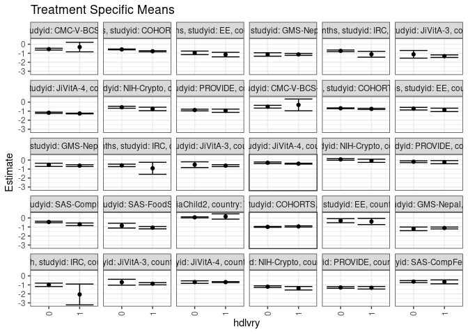

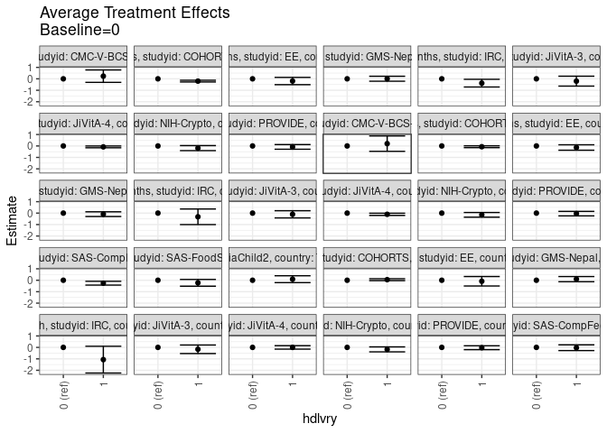

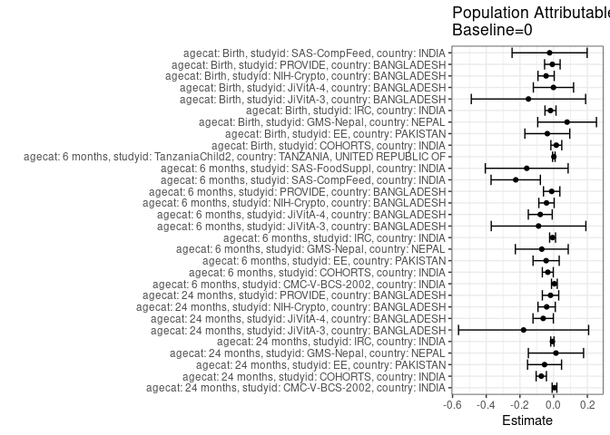

## Results Table

### Parameter: TSM

| agecat | studyid | country | intervention_level | baseline_level | estimate | ci_lower | ci_upper |
| --- | --- | --- | --- | --- | --- | --- | --- |
| Birth | COHORTS | INDIA | 0 | NA | -0.9915022 | -1.0396192 | -0.9433851 |
| Birth | COHORTS | INDIA | 1 | NA | -0.9403829 | -1.0079910 | -0.8727748 |
| Birth | EE | PAKISTAN | 0 | NA | -0.3034816 | -0.5305132 | -0.0764500 |
| Birth | EE | PAKISTAN | 1 | NA | -0.3916937 | -0.7356053 | -0.0477821 |
| Birth | GMS-Nepal | NEPAL | 0 | NA | -1.2075727 | -1.4072303 | -1.0079151 |
| Birth | GMS-Nepal | NEPAL | 1 | NA | -1.1100131 | -1.2131260 | -1.0069003 |
| Birth | IRC | INDIA | 0 | NA | -0.9918991 | -1.1804921 | -0.8033061 |
| Birth | IRC | INDIA | 1 | NA | -2.0600000 | -3.2141159 | -0.9058841 |
| Birth | JiVitA-3 | BANGLADESH | 0 | NA | -0.7037714 | -1.0306383 | -0.3769046 |
| Birth | JiVitA-3 | BANGLADESH | 1 | NA | -0.8695364 | -0.9938429 | -0.7452299 |
| Birth | JiVitA-4 | BANGLADESH | 0 | NA | -0.6897207 | -0.8302553 | -0.5491862 |
| Birth | JiVitA-4 | BANGLADESH | 1 | NA | -0.6908233 | -0.7459605 | -0.6356862 |
| Birth | NIH-Crypto | BANGLADESH | 0 | NA | -1.1994291 | -1.2936869 | -1.1051714 |
| Birth | NIH-Crypto | BANGLADESH | 1 | NA | -1.3717868 | -1.5661149 | -1.1774587 |
| Birth | PROVIDE | BANGLADESH | 0 | NA | -1.2908257 | -1.3822056 | -1.1994458 |
| Birth | PROVIDE | BANGLADESH | 1 | NA | -1.3179154 | -1.4603917 | -1.1754392 |
| Birth | SAS-CompFeed | INDIA | 0 | NA | -0.6331755 | -0.7465687 | -0.5197823 |
| Birth | SAS-CompFeed | INDIA | 1 | NA | -0.6612605 | -0.8794821 | -0.4430390 |
| 6 months | CMC-V-BCS-2002 | INDIA | 0 | NA | -0.5089262 | -0.6640006 | -0.3538519 |
| 6 months | CMC-V-BCS-2002 | INDIA | 1 | NA | -0.3072917 | -0.9616161 | 0.3470328 |
| 6 months | COHORTS | INDIA | 0 | NA | -0.6813861 | -0.7273450 | -0.6354272 |
| 6 months | COHORTS | INDIA | 1 | NA | -0.7484714 | -0.8141472 | -0.6827957 |
| 6 months | EE | PAKISTAN | 0 | NA | -0.7250284 | -0.8673702 | -0.5826865 |
| 6 months | EE | PAKISTAN | 1 | NA | -0.8603643 | -1.0507584 | -0.6699703 |
| 6 months | GMS-Nepal | NEPAL | 0 | NA | -0.5289448 | -0.7067065 | -0.3511832 |
| 6 months | GMS-Nepal | NEPAL | 1 | NA | -0.6204930 | -0.7208906 | -0.5200954 |
| 6 months | IRC | INDIA | 0 | NA | -0.5926333 | -0.7305001 | -0.4547666 |
| 6 months | IRC | INDIA | 1 | NA | -0.9137500 | -1.5807163 | -0.2467837 |
| 6 months | JiVitA-3 | BANGLADESH | 0 | NA | -0.5149950 | -0.8335392 | -0.1964508 |
| 6 months | JiVitA-3 | BANGLADESH | 1 | NA | -0.6201944 | -0.7242709 | -0.5161179 |
| 6 months | JiVitA-4 | BANGLADESH | 0 | NA | -0.2966707 | -0.3801430 | -0.2131984 |
| 6 months | JiVitA-4 | BANGLADESH | 1 | NA | -0.4020820 | -0.4524989 | -0.3516650 |
| 6 months | NIH-Crypto | BANGLADESH | 0 | NA | 0.0721591 | -0.0174178 | 0.1617360 |
| 6 months | NIH-Crypto | BANGLADESH | 1 | NA | -0.0789733 | -0.2594815 | 0.1015349 |
| 6 months | PROVIDE | BANGLADESH | 0 | NA | -0.1873936 | -0.2829343 | -0.0918529 |
| 6 months | PROVIDE | BANGLADESH | 1 | NA | -0.2336029 | -0.4040658 | -0.0631399 |
| 6 months | SAS-CompFeed | INDIA | 0 | NA | -0.4484212 | -0.5307327 | -0.3661098 |
| 6 months | SAS-CompFeed | INDIA | 1 | NA | -0.7057833 | -0.8527199 | -0.5588466 |
| 6 months | SAS-FoodSuppl | INDIA | 0 | NA | -0.8523583 | -1.1178596 | -0.5868569 |
| 6 months | SAS-FoodSuppl | INDIA | 1 | NA | -1.0764034 | -1.2071387 | -0.9456682 |
| 6 months | TanzaniaChild2 | TANZANIA, UNITED REPUBLIC OF | 0 | NA | 0.0676569 | 0.0126018 | 0.1227121 |
| 6 months | TanzaniaChild2 | TANZANIA, UNITED REPUBLIC OF | 1 | NA | 0.1603115 | -0.1333725 | 0.4539955 |
| 24 months | CMC-V-BCS-2002 | INDIA | 0 | NA | -0.5487673 | -0.6500596 | -0.4474751 |
| 24 months | CMC-V-BCS-2002 | INDIA | 1 | NA | -0.3150000 | -0.8468853 | 0.2168853 |
| 24 months | COHORTS | INDIA | 0 | NA | -0.5786669 | -0.6238399 | -0.5334939 |
| 24 months | COHORTS | INDIA | 1 | NA | -0.7797620 | -0.8436516 | -0.7158724 |
| 24 months | EE | PAKISTAN | 0 | NA | -0.9564422 | -1.1524956 | -0.7603887 |
| 24 months | EE | PAKISTAN | 1 | NA | -1.1493386 | -1.4020529 | -0.8966242 |
| 24 months | GMS-Nepal | NEPAL | 0 | NA | -1.1376397 | -1.3264879 | -0.9487915 |
| 24 months | GMS-Nepal | NEPAL | 1 | NA | -1.1299666 | -1.2348668 | -1.0250663 |
| 24 months | IRC | INDIA | 0 | NA | -0.7384331 | -0.8312559 | -0.6456103 |
| 24 months | IRC | INDIA | 1 | NA | -1.1158333 | -1.4387631 | -0.7929036 |
| 24 months | JiVitA-3 | BANGLADESH | 0 | NA | -1.1205038 | -1.5443027 | -0.6967048 |
| 24 months | JiVitA-3 | BANGLADESH | 1 | NA | -1.3245075 | -1.4664720 | -1.1825431 |
| 24 months | JiVitA-4 | BANGLADESH | 0 | NA | -1.1801404 | -1.2510762 | -1.1092046 |
| 24 months | JiVitA-4 | BANGLADESH | 1 | NA | -1.2605291 | -1.2999335 | -1.2211246 |
| 24 months | NIH-Crypto | BANGLADESH | 0 | NA | -0.5688734 | -0.6792886 | -0.4584582 |
| 24 months | NIH-Crypto | BANGLADESH | 1 | NA | -0.7566354 | -0.9480025 | -0.5652682 |
| 24 months | PROVIDE | BANGLADESH | 0 | NA | -0.8744432 | -0.9693007 | -0.7795856 |
| 24 months | PROVIDE | BANGLADESH | 1 | NA | -0.9565782 | -1.1371868 | -0.7759696 |

### Parameter: E(Y)

| agecat | studyid | country | intervention_level | baseline_level | estimate | ci_lower | ci_upper |
| --- | --- | --- | --- | --- | --- | --- | --- |
| Birth | COHORTS | INDIA | NA | NA | -0.9755867 | -1.0106993 | -0.9404741 |
| Birth | EE | PAKISTAN | NA | NA | -0.3410000 | -0.5302198 | -0.1517802 |
| Birth | GMS-Nepal | NEPAL | NA | NA | -1.1277349 | -1.2174865 | -1.0379833 |
| Birth | IRC | INDIA | NA | NA | -1.0105831 | -1.1973019 | -0.8238643 |
| Birth | JiVitA-3 | BANGLADESH | NA | NA | -0.8532192 | -0.9644938 | -0.7419446 |
| Birth | JiVitA-4 | BANGLADESH | NA | NA | -0.6907341 | -0.7437042 | -0.6377640 |
| Birth | NIH-Crypto | BANGLADESH | NA | NA | -1.2441513 | -1.3281130 | -1.1601897 |
| Birth | PROVIDE | BANGLADESH | NA | NA | -1.2984586 | -1.3752758 | -1.2216415 |
| Birth | SAS-CompFeed | INDIA | NA | NA | -0.6570846 | -0.8496671 | -0.4645022 |
| 6 months | CMC-V-BCS-2002 | INDIA | NA | NA | -0.5045068 | -0.6566169 | -0.3523968 |
| 6 months | COHORTS | INDIA | NA | NA | -0.7160077 | -0.7492815 | -0.6827338 |
| 6 months | EE | PAKISTAN | NA | NA | -0.7695800 | -0.8839306 | -0.6552294 |
| 6 months | GMS-Nepal | NEPAL | NA | NA | -0.5992551 | -0.6878945 | -0.5106156 |
| 6 months | IRC | INDIA | NA | NA | -0.5989297 | -0.7344491 | -0.4634104 |
| 6 months | JiVitA-3 | BANGLADESH | NA | NA | -0.6044910 | -0.7122040 | -0.4967781 |
| 6 months | JiVitA-4 | BANGLADESH | NA | NA | -0.3760651 | -0.4191017 | -0.3330285 |
| 6 months | NIH-Crypto | BANGLADESH | NA | NA | 0.0297622 | -0.0491685 | 0.1086930 |
| 6 months | PROVIDE | BANGLADESH | NA | NA | -0.1990907 | -0.2817968 | -0.1163845 |
| 6 months | SAS-CompFeed | INDIA | NA | NA | -0.6734421 | -0.8121314 | -0.5347528 |
| 6 months | SAS-FoodSuppl | INDIA | NA | NA | -1.0121579 | -1.1280429 | -0.8962729 |
| 6 months | TanzaniaChild2 | TANZANIA, UNITED REPUBLIC OF | NA | NA | 0.0688763 | 0.0147308 | 0.1230218 |
| 24 months | CMC-V-BCS-2002 | INDIA | NA | NA | -0.5436992 | -0.6434110 | -0.4439874 |
| 24 months | COHORTS | INDIA | NA | NA | -0.6520577 | -0.6860033 | -0.6181122 |
| 24 months | EE | PAKISTAN | NA | NA | -1.0103892 | -1.1580613 | -0.8627171 |
| 24 months | GMS-Nepal | NEPAL | NA | NA | -1.1238388 | -1.2161263 | -1.0315513 |
| 24 months | IRC | INDIA | NA | NA | -0.7458150 | -0.8368180 | -0.6548120 |
| 24 months | JiVitA-3 | BANGLADESH | NA | NA | -1.2989273 | -1.4377964 | -1.1600583 |
| 24 months | JiVitA-4 | BANGLADESH | NA | NA | -1.2421463 | -1.2763113 | -1.2079812 |
| 24 months | NIH-Crypto | BANGLADESH | NA | NA | -0.6103502 | -0.7050157 | -0.5156847 |
| 24 months | PROVIDE | BANGLADESH | NA | NA | -0.8928670 | -0.9755153 | -0.8102187 |

### Parameter: ATE

| agecat | studyid | country | intervention_level | baseline_level | estimate | ci_lower | ci_upper |
| --- | --- | --- | --- | --- | --- | --- | --- |
| Birth | COHORTS | INDIA | 0 | 0 | 0.0000000 | 0.0000000 | 0.0000000 |
| Birth | COHORTS | INDIA | 1 | 0 | 0.0511193 | -0.0317484 | 0.1339870 |
| Birth | EE | PAKISTAN | 0 | 0 | 0.0000000 | 0.0000000 | 0.0000000 |
| Birth | EE | PAKISTAN | 1 | 0 | -0.0882121 | -0.5027967 | 0.3263724 |
| Birth | GMS-Nepal | NEPAL | 0 | 0 | 0.0000000 | 0.0000000 | 0.0000000 |
| Birth | GMS-Nepal | NEPAL | 1 | 0 | 0.0975596 | -0.1273627 | 0.3224819 |
| Birth | IRC | INDIA | 0 | 0 | 0.0000000 | 0.0000000 | 0.0000000 |
| Birth | IRC | INDIA | 1 | 0 | -1.0681009 | -2.2375241 | 0.1013224 |
| Birth | JiVitA-3 | BANGLADESH | 0 | 0 | 0.0000000 | 0.0000000 | 0.0000000 |
| Birth | JiVitA-3 | BANGLADESH | 1 | 0 | -0.1657650 | -0.5382027 | 0.2066728 |
| Birth | JiVitA-4 | BANGLADESH | 0 | 0 | 0.0000000 | 0.0000000 | 0.0000000 |
| Birth | JiVitA-4 | BANGLADESH | 1 | 0 | -0.0011026 | -0.1513228 | 0.1491176 |
| Birth | NIH-Crypto | BANGLADESH | 0 | 0 | 0.0000000 | 0.0000000 | 0.0000000 |
| Birth | NIH-Crypto | BANGLADESH | 1 | 0 | -0.1723577 | -0.3891646 | 0.0444492 |
| Birth | PROVIDE | BANGLADESH | 0 | 0 | 0.0000000 | 0.0000000 | 0.0000000 |
| Birth | PROVIDE | BANGLADESH | 1 | 0 | -0.0270897 | -0.1964885 | 0.1423090 |
| Birth | SAS-CompFeed | INDIA | 0 | 0 | 0.0000000 | 0.0000000 | 0.0000000 |
| Birth | SAS-CompFeed | INDIA | 1 | 0 | -0.0280850 | -0.2799825 | 0.2238125 |
| 6 months | CMC-V-BCS-2002 | INDIA | 0 | 0 | 0.0000000 | 0.0000000 | 0.0000000 |
| 6 months | CMC-V-BCS-2002 | INDIA | 1 | 0 | 0.2016346 | -0.4708151 | 0.8740843 |
| 6 months | COHORTS | INDIA | 0 | 0 | 0.0000000 | 0.0000000 | 0.0000000 |
| 6 months | COHORTS | INDIA | 1 | 0 | -0.0670853 | -0.1468573 | 0.0126866 |
| 6 months | EE | PAKISTAN | 0 | 0 | 0.0000000 | 0.0000000 | 0.0000000 |
| 6 months | EE | PAKISTAN | 1 | 0 | -0.1353359 | -0.3732256 | 0.1025538 |
| 6 months | GMS-Nepal | NEPAL | 0 | 0 | 0.0000000 | 0.0000000 | 0.0000000 |
| 6 months | GMS-Nepal | NEPAL | 1 | 0 | -0.0915482 | -0.2959156 | 0.1128192 |
| 6 months | IRC | INDIA | 0 | 0 | 0.0000000 | 0.0000000 | 0.0000000 |
| 6 months | IRC | INDIA | 1 | 0 | -0.3211167 | -1.0021830 | 0.3599496 |
| 6 months | JiVitA-3 | BANGLADESH | 0 | 0 | 0.0000000 | 0.0000000 | 0.0000000 |
| 6 months | JiVitA-3 | BANGLADESH | 1 | 0 | -0.1051994 | -0.4184554 | 0.2080565 |
| 6 months | JiVitA-4 | BANGLADESH | 0 | 0 | 0.0000000 | 0.0000000 | 0.0000000 |
| 6 months | JiVitA-4 | BANGLADESH | 1 | 0 | -0.1054113 | -0.2010608 | -0.0097617 |
| 6 months | NIH-Crypto | BANGLADESH | 0 | 0 | 0.0000000 | 0.0000000 | 0.0000000 |
| 6 months | NIH-Crypto | BANGLADESH | 1 | 0 | -0.1511324 | -0.3548122 | 0.0525474 |
| 6 months | PROVIDE | BANGLADESH | 0 | 0 | 0.0000000 | 0.0000000 | 0.0000000 |
| 6 months | PROVIDE | BANGLADESH | 1 | 0 | -0.0462093 | -0.2417452 | 0.1493266 |
| 6 months | SAS-CompFeed | INDIA | 0 | 0 | 0.0000000 | 0.0000000 | 0.0000000 |
| 6 months | SAS-CompFeed | INDIA | 1 | 0 | -0.2573620 | -0.4212560 | -0.0934681 |
| 6 months | SAS-FoodSuppl | INDIA | 0 | 0 | 0.0000000 | 0.0000000 | 0.0000000 |
| 6 months | SAS-FoodSuppl | INDIA | 1 | 0 | -0.2240452 | -0.5204356 | 0.0723453 |
| 6 months | TanzaniaChild2 | TANZANIA, UNITED REPUBLIC OF | 0 | 0 | 0.0000000 | 0.0000000 | 0.0000000 |
| 6 months | TanzaniaChild2 | TANZANIA, UNITED REPUBLIC OF | 1 | 0 | 0.0926546 | -0.2062689 | 0.3915781 |
| 24 months | CMC-V-BCS-2002 | INDIA | 0 | 0 | 0.0000000 | 0.0000000 | 0.0000000 |
| 24 months | CMC-V-BCS-2002 | INDIA | 1 | 0 | 0.2337673 | -0.3076771 | 0.7752117 |
| 24 months | COHORTS | INDIA | 0 | 0 | 0.0000000 | 0.0000000 | 0.0000000 |
| 24 months | COHORTS | INDIA | 1 | 0 | -0.2010951 | -0.2785166 | -0.1236735 |
| 24 months | EE | PAKISTAN | 0 | 0 | 0.0000000 | 0.0000000 | 0.0000000 |
| 24 months | EE | PAKISTAN | 1 | 0 | -0.1928964 | -0.5111334 | 0.1253405 |
| 24 months | GMS-Nepal | NEPAL | 0 | 0 | 0.0000000 | 0.0000000 | 0.0000000 |
| 24 months | GMS-Nepal | NEPAL | 1 | 0 | 0.0076731 | -0.2087160 | 0.2240623 |
| 24 months | IRC | INDIA | 0 | 0 | 0.0000000 | 0.0000000 | 0.0000000 |
| 24 months | IRC | INDIA | 1 | 0 | -0.3774002 | -0.7134057 | -0.0413948 |
| 24 months | JiVitA-3 | BANGLADESH | 0 | 0 | 0.0000000 | 0.0000000 | 0.0000000 |
| 24 months | JiVitA-3 | BANGLADESH | 1 | 0 | -0.2040038 | -0.6364611 | 0.2284536 |
| 24 months | JiVitA-4 | BANGLADESH | 0 | 0 | 0.0000000 | 0.0000000 | 0.0000000 |
| 24 months | JiVitA-4 | BANGLADESH | 1 | 0 | -0.0803887 | -0.1603789 | -0.0003984 |
| 24 months | NIH-Crypto | BANGLADESH | 0 | 0 | 0.0000000 | 0.0000000 | 0.0000000 |
| 24 months | NIH-Crypto | BANGLADESH | 1 | 0 | -0.1877620 | -0.4080770 | 0.0325531 |
| 24 months | PROVIDE | BANGLADESH | 0 | 0 | 0.0000000 | 0.0000000 | 0.0000000 |
| 24 months | PROVIDE | BANGLADESH | 1 | 0 | -0.0821351 | -0.2859294 | 0.1216593 |

### Parameter: PAR

| agecat | studyid | country | intervention_level | baseline_level | estimate | ci_lower | ci_upper |
| --- | --- | --- | --- | --- | --- | --- | --- |
| Birth | COHORTS | INDIA | 0 | NA | 0.0159155 | -0.0163798 | 0.0482108 |
| Birth | EE | PAKISTAN | 0 | NA | -0.0375184 | -0.1707049 | 0.0956680 |
| Birth | GMS-Nepal | NEPAL | 0 | NA | 0.0798378 | -0.0944828 | 0.2541584 |
| Birth | IRC | INDIA | 0 | NA | -0.0186840 | -0.0514705 | 0.0141025 |
| Birth | JiVitA-3 | BANGLADESH | 0 | NA | -0.1494477 | -0.4886878 | 0.1897923 |
| Birth | JiVitA-4 | BANGLADESH | 0 | NA | -0.0010133 | -0.1203970 | 0.1183703 |
| Birth | NIH-Crypto | BANGLADESH | 0 | NA | -0.0447222 | -0.0929817 | 0.0035372 |
| Birth | PROVIDE | BANGLADESH | 0 | NA | -0.0076330 | -0.0537614 | 0.0384955 |
| Birth | SAS-CompFeed | INDIA | 0 | NA | -0.0239091 | -0.2466022 | 0.1987840 |
| 6 months | CMC-V-BCS-2002 | INDIA | 0 | NA | 0.0044194 | -0.0126632 | 0.0215020 |
| 6 months | COHORTS | INDIA | 0 | NA | -0.0346216 | -0.0670754 | -0.0021678 |
| 6 months | EE | PAKISTAN | 0 | NA | -0.0445516 | -0.1221485 | 0.0330453 |
| 6 months | GMS-Nepal | NEPAL | 0 | NA | -0.0703102 | -0.2271948 | 0.0865743 |
| 6 months | IRC | INDIA | 0 | NA | -0.0062964 | -0.0238639 | 0.0112711 |
| 6 months | JiVitA-3 | BANGLADESH | 0 | NA | -0.0894960 | -0.3702369 | 0.1912449 |
| 6 months | JiVitA-4 | BANGLADESH | 0 | NA | -0.0793944 | -0.1503757 | -0.0084130 |
| 6 months | NIH-Crypto | BANGLADESH | 0 | NA | -0.0423969 | -0.0880451 | 0.0032514 |
| 6 months | PROVIDE | BANGLADESH | 0 | NA | -0.0116971 | -0.0602124 | 0.0368182 |
| 6 months | SAS-CompFeed | INDIA | 0 | NA | -0.2250209 | -0.3713459 | -0.0786958 |
| 6 months | SAS-FoodSuppl | INDIA | 0 | NA | -0.1597996 | -0.4055167 | 0.0859174 |
| 6 months | TanzaniaChild2 | TANZANIA, UNITED REPUBLIC OF | 0 | NA | 0.0012194 | -0.0063579 | 0.0087967 |
| 24 months | CMC-V-BCS-2002 | INDIA | 0 | NA | 0.0050681 | -0.0089078 | 0.0190440 |
| 24 months | COHORTS | INDIA | 0 | NA | -0.0733908 | -0.1038919 | -0.0428898 |
| 24 months | EE | PAKISTAN | 0 | NA | -0.0539471 | -0.1548455 | 0.0469513 |
| 24 months | GMS-Nepal | NEPAL | 0 | NA | 0.0138009 | -0.1501078 | 0.1777095 |
| 24 months | IRC | INDIA | 0 | NA | -0.0073819 | -0.0171941 | 0.0024303 |
| 24 months | JiVitA-3 | BANGLADESH | 0 | NA | -0.1784236 | -0.5644758 | 0.2076287 |
| 24 months | JiVitA-4 | BANGLADESH | 0 | NA | -0.0620058 | -0.1223373 | -0.0016743 |
| 24 months | NIH-Crypto | BANGLADESH | 0 | NA | -0.0414768 | -0.0928679 | 0.0099143 |
| 24 months | PROVIDE | BANGLADESH | 0 | NA | -0.0184239 | -0.0669343 | 0.0300866 |